# Summary of models included in rtedem

K Todd-Brown (ktoddbrown@gmail.com)

2015-11-06

*rtedem* is designed to allow for easy terrestrial decomposition data-model integration. There are several soil decomposition models already coded including: CENTURY, TECO, CLM, and YASSO07. Also included is a flexible microbial explicit model (MEM) which has microbial growth and metabolism, extracellular enzyme kinetics, microbial dormancy, and physical protection of organic carbon. Currently this is a single community model and does not take into account microbial or substrate heterogeneity (beyond a complex and simple carbon pool).

```r
library(ggplot2)
library(reshape2)
library(plyr)
library(Matrix)
library(rtedem)
```

Traditional soil decomposition models have multiple pools binned by soil quality with a range of decomposition rates.

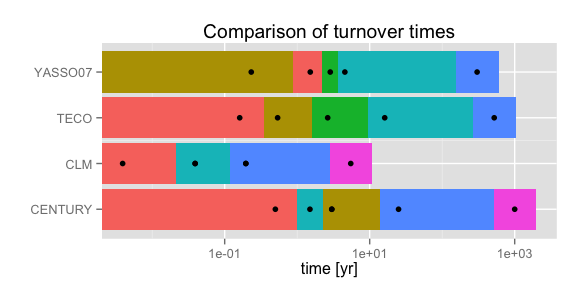

```r
codedParameters <- publishedParameters()
minMaxBounds <- makeModelBounds(codedParameters)
turnovers <- ldply(names(minMaxBounds), function(xx){
  ans <- minMaxBounds[[xx]][grepl('K', minMaxBounds[[xx]]$name),]
  ans[,c('true', 'min', 'max')] <- ans[,c('true', 'min', 'max')] * -1
  ans$model <- xx
  return(ans)
})
turnovers$modelIndex <- as.numeric(as.factor(turnovers$model))
yAxis <- unique(turnovers[,c('model', 'modelIndex')])
ggplot(turnovers) + geom_rect(aes(ymax=modelIndex+0.45, ymin=modelIndex-0.45, xmax=min/365, xmin=max/365, fill=name)) +
  geom_point(aes(y=modelIndex, x=true/365)) +
  scale_x_log10() + scale_y_continuous(breaks=yAxis$modelIndex, labels=yAxis$model) +
  labs(title='Comparison of turnover times', y='', x='time [yr]') + guides(fill=FALSE)
```

Mathematically this can be expressed as $dC=A*K*C$ where C is the carbon pools, $A$ the transfers between those pools, and $K$ the decay rate of the pools.

```r
decayMatrix <- llply(codedParameters, function(xx){
  Turnover <- Matrix(diag(xx$tau/365))
  A <- matrix(data=0, nrow=dim(Turnover)[1], ncol=dim(Turnover)[2])
  A[as.numeric(gsub('A', '', xx$trans$name))] <- xx$trans$val
  return(list(turnover = Turnover, transfer=Matrix(A), K=Matrix(diag(1/(xx$tau/365)))))
})
```

For the published models coded in this package the transfer matricies are:

```r
l_ply(names(codedParameters), function(xx){
  #cat(xx,' turnover [year]:\n');print(decayMatrix[[xx]]$turnover)
  cat(xx, ' transfer Matrix:\n');print(decayMatrix[[xx]]$transfer)
})
```

```
## YASSO07  transfer Matrix:
## 5 x 5 sparse Matrix of class "dgCMatrix"
##
## [1,] .    0.32 0.01 0.93 .
## [2,] 0.34 .    .    .    .
## [3,] .    .    .    0.01 .
## [4,] .    .    0.92 .    .
## [5,] 0.04 0.04 0.04 0.04 .
## CLM  transfer Matrix:
## 6 x 6 sparse Matrix of class "dtCMatrix"
##
## [1,] .    .    .    .    .    .
## [2,] .    .    .    .    .    .
## [3,] .    .    .    .    .    .
## [4,] 0.61 .    .    .    .    .
```

[output cut: 19 more lines]

And associated decay matricies are:

```r
l_ply(names(codedParameters), function(xx){
  cat(xx, 'decay Matrix (1/tau*transfer):\n')
  A <- decayMatrix[[xx]]$transfer
  diag(A) <- -1
  print(decayMatrix[[xx]]$K %*% A)
})
```

```
## YASSO07 decay Matrix (1/tau*transfer):
## 5 x 5 sparse Matrix of class "dgCMatrix"
##
## [1,] -0.660000  0.211200  0.006600  0.613800  .
## [2,]  1.462000 -4.300000  .         .         .
## [3,]  .         .        -0.350000  0.003500  .
## [4,]  .         .         0.202400 -0.220000  .
## [5,]  0.000132  0.000132  0.000132  0.000132 -0.0033
## CLM decay Matrix (1/tau*transfer):
## 6 x 6 sparse Matrix of class "dtCMatrix"
##
## [1,] -255.5000   .       .          .       .        .
## [2,]    .      -25.5500  .          .       .        .
## [3,]    .        .      -5.110000   .       .        .
## [4,]   15.5855   .       .        -25.5500  .        .
```

[output cut: 19 more lines]

This results in the following model predictions assuming that 20% of the carbon is split equally between the ‘young’ pools.

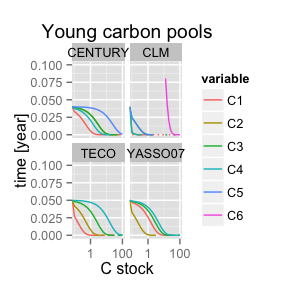

```r
poolOuts <- ldply(names(codedParameters), function(modelStr){
  numPools <- length(codedParameters[[modelStr]]$tau)
  par <- c(codedParameters[[modelStr]]$tau/365, codedParameters[[modelStr]]$trans$val, rep(0.2/(numPools-1), length=numPools-1))
  names(par) <- c(paste('tau', 1:numPools, sep=''), codedParameters[[modelStr]]$trans$name, paste('a', 1:(numPools-1), sep=''))

  temp <- runModel(par=par, timeArr=10^seq(-1, 2, by=0.1), cModel=dC.firstOrderModel, C_bulk=1, dt=1/365, allocationStr='a')
  temp$model <- modelStr
  return(temp)
})
poolOuts <- melt(poolOuts, id.vars=c('time', 'label', 'model'))
ggplot(poolOuts) + geom_line(aes(x=time, y=value, color=variable, group=paste(model, variable))) + facet_wrap(~model) + scale_x_log10() + ylim(c(0, 0.1)) + labs(title='Young carbon pools', y='time [year]', x='C stock')
```

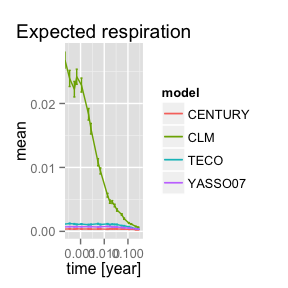

```r
CO2Outs <- ldply(names(codedParameters), function(modelStr){
  numPools <- length(codedParameters[[modelStr]]$tau)
  par <- c(codedParameters[[modelStr]]$tau, codedParameters[[modelStr]]$trans$val, rep(0.2/(numPools-1), length=numPools-1))
  names(par) <- c(paste('tau', 1:numPools, sep=''), codedParameters[[modelStr]]$trans$name, paste('a', 1:(numPools-1), sep=''))

  temp <- createSynData(par=par, timeArr=10^seq(-1, 2, by=0.1), cModel=dC.firstOrderModel, C_bulk=1, dt=1, allocationStr='a')
  temp$model <- modelStr
  return(temp)
})

ggplot(CO2Outs) + geom_line(aes(x=time/365, y=mean, color=model)) + geom_errorbar(aes(x=time/365, ymin=mean-sd, ymax=mean+sd, color=model)) + scale_x_log10() +  labs(title='Expected respiration', x='time [year]', x='CO2 flux [g CO2-C g^-1 soil-C day^-1]')
```

In addition to the traditional first order linear models above there is also a microbial explicit model (MEM).

```r
makePlots <- function(par, pools, timeArr=10^seq(-1, 0, length=20)*365){
  totalC <- sum(unlist(pools))
  #poolIndex <- list(simple=1, dormant=2, protect_S=3, protect_C=4, biomass=5, enzyme=6, complex=7)
  poolIndex <- lapply(names(pools), function(xx){which(names(pools) %in% xx)})
  names(poolIndex) <- names(pools)

  parFull <- (unlist(pools)/totalC)[-max(unlist(poolIndex))]
  names(parFull) <- sprintf('a%d', 1:(length(parFull)))
  parFull <- c(unlist(par), parFull)

  poolOuts <- runModel(par=parFull, timeArr=timeArr, cModel=dC.biomassModel, C_bulk=totalC, dt=1, poolAssignment=poolIndex, rateFlags=list(enz='MM', uptake='MM', prod='uptake', sorb='carryCapacity'), allocationStr='a')
  poolOuts <- melt(poolOuts, id.vars=c('time', 'label'))
  ans <- list(pools = ggplot(poolOuts) + geom_line(aes(x=time, y=value))  + labs(title='Carbon pools', x='time [day]', y='C stock')+ facet_wrap(~variable, scales='free'))

  CO2Outs <- createSynData(par=parFull, timeArr=timeArr, cModel=dC.biomassModel, C_bulk=totalC, dt=1, poolAssignment=poolIndex, rateFlags=list(enz='MM', uptake='MM', prod='uptake', sorb='carryCapacity'), allocationStr='a')

  ans$CO2 <- ggplot(CO2Outs) + geom_line(aes(x=time, y=mean)) + geom_errorbar(aes(x=time, ymin=mean-sd, ymax=mean+sd)) +  labs(title='Synthetic respiration', x='time [day]', y='CO2 flux [g CO2-C g^-1 soil-C day^-1]')

  return(ans)
}
```

```r
par <- list(v_enz=5, km_enz=2,
                v_up=1, km_up=1, cue=0.75,
                basal=0.1,
                turnover_b=0.05,
                enzProd=0.01, enzCost=1,
                turnover_e=0.005,
                dormancy_rate=1e-3, S_dormancy=0.1,
                sorb_rate=0.01, desorb_rate=0.01, carbonCapacity=50)
pools <- list(protect_S=0.3, protect_C=3)
##Assume dP_C and dP_S are equal to 0
pools$complex <- par$desorb_rate/par$sorb_rate*(1/pools$protect_C-1/par$carbonCapacity)^-1
pools$simple <- par$desorb_rate/par$sorb_rate*(1/pools$protect_S-1/par$carbonCapacity)^-1

##Assume dB equal to 0
pools$biomass <- pools$simple*par$v_up*(par$cue) -
                      par$km_up*(par$basal+par$turnover_b)

##Assume most of microbes are dormant
##TODO dormancy seems to destablize model, not sure what's up with this
pools$dormant <- pools$biomass*10

##Assume that enzymes should be proportional to biomass
pools$enzyme <- pools$biomass*par$enzProd
```

Run a simple enzyme decomposition model

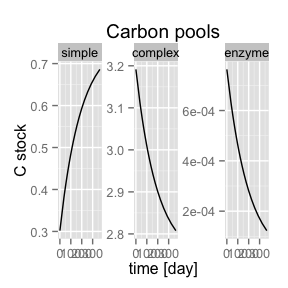

```r
temp <- makePlots(par, pools[c('simple', 'complex', 'enzyme')])
temp$pools
```

Run a simple biomass explicit decomposition model

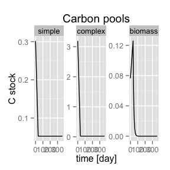

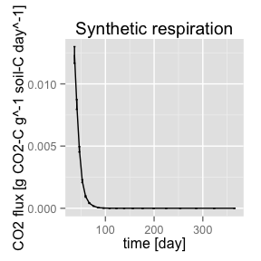

```r
temp <- makePlots(par, pools[c('simple', 'complex', 'biomass')])
temp$pools; temp$CO2
```

Run biomass+enzyme decomposition model

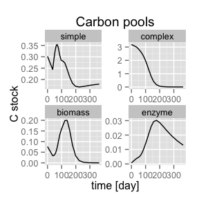

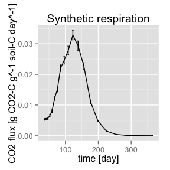

```r
temp <- makePlots(par, pools[c('simple', 'complex', 'biomass', 'enzyme')])
temp$pools; temp$CO2
```

Run the sorption/desorption submodel

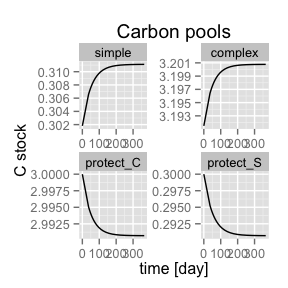

```r
temp <- makePlots(par, pools[c('simple', 'complex', 'protect_C', 'protect_S')])
temp$pools
```

Run full biomass+enzyme with sorption/desorption model

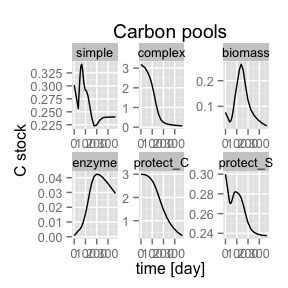

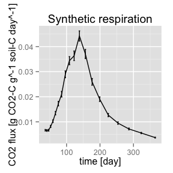

```r
temp <- makePlots(par, pools[c('simple', 'complex', 'biomass', 'enzyme', 'protect_C', 'protect_S')])
temp$pools; temp$CO2
```

Run full biomass+enzyme with sorption/desorption and dormancy model

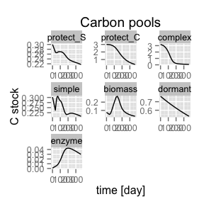

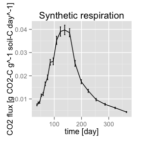

```r
temp <- makePlots(par, pools)
temp$pools; temp$CO2
```